# XGBoost for Image Recognition

40.319 Statistical and Machine Learning, Term 7, 2022

Chia Yu Ying, Hour Youlinsereydevid

4/21/2022

# Libraries used in this tutorial

```r
library(xgboost)
library(readr)
library(stringr)
library(caret)
library(car)
library(reshape2)
```

# Overview

- Motivation: Classification and Number Recognition using MNIST dataset
- Bias-Variance trade-off
- Weak Learners
- Ensemble Learning/ Methods
- Bagging
- Boosting
- Boosting Algorithms
- Backtracking
- Extreme Gradient Boosting
- Gradient Boosting
- Decisions Trees
- Recap: log(odds) and log(likelihood)
- Loss function For Gradient Boosting
- Big Idea of Gradient Boosting
- Gradient Boosting (Gradient Boosted Trees) - Diabetes Example
- Gradient Boosting (Gradient Boosted Trees) - Math Explained
- L1 & L2 Regularizers
- Code Implementation
- Resources
- Annex

# Motivation

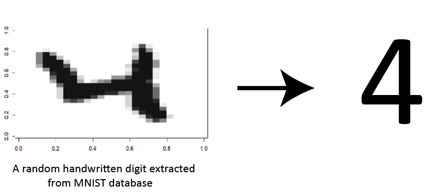

- While it is easy for human brain to instantly associate the handwritten image (left) to the number 4, it is not as straightforward for computers to do so
- How can we train computers to “read” numbers from images?

# Motivation

- In class (week 8), we learnt character recognition by means of Kernel Density Function. Specifically, we use radial basis function to get empirical density functions and use maximum log likelihood to select character.
- In this tutorial, let’s take a look at how we can perform image classification (on handwritten numbers using MNIST dataset) through the use of **Ensemble learning**

# Bias-Variance Trade-Off

- A low bias and a low variance are the two most fundamental features expected when training a model, though they most often vary in opposite directions
- We want our model to have enough degrees of freedom to resolve the underlying complexity of the (train) data that we are working with, but we also not want too much degrees of freedom to avoid high variance on the (test) data

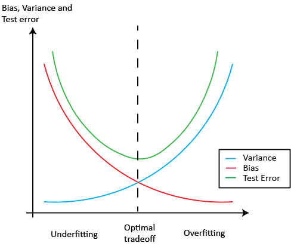

# Weak Learners

- In ensemble learning, we call **weak learners** models that are used for designing more complex models by combining several of them
- Usually, these weak learners perform not so well by themselves either because they have a high bias or because they have too much variance
- This is where the bias-variance trade-off comes in where we try to find a balance between bias and variance by using ensemble learning

# Ensemble Learning

- The old saying “Unity is Strength” expresses pretty well the underlying idea that rules the very powerful ensemble methods in machine learning

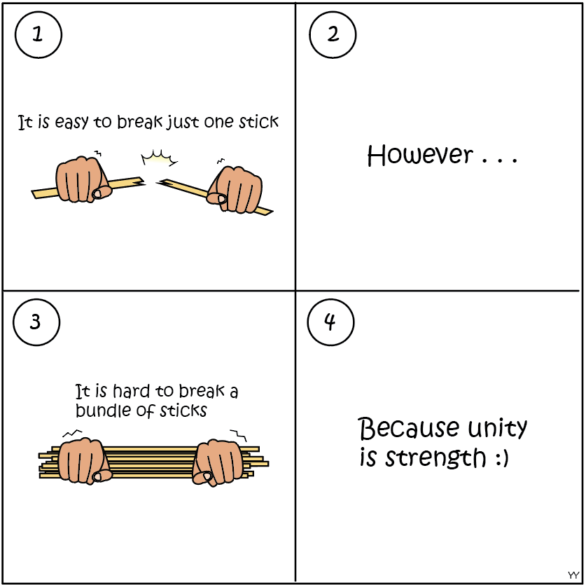

# Ensemble Learning

- Ensemble methods aim at improving predictability in models by combining several weak learners to make one reliable strong learner, thus increasing the accuracy of the model
- Ensemble methods are ideal for both regression and classification, where they reduce bias and variance to boost the accuracy of models

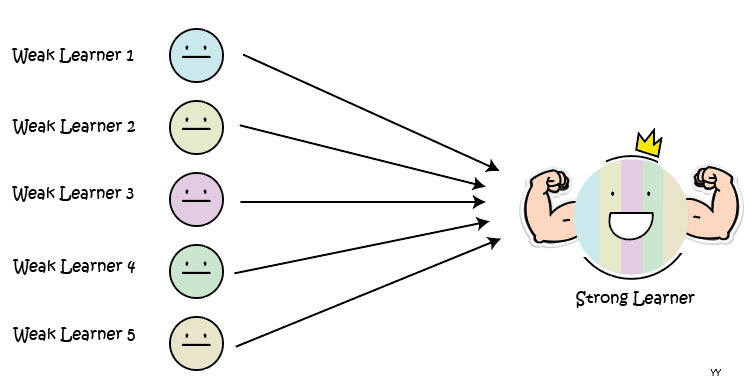

# Ensemble Methods

- There are mainly two types of ensemble methods, *homogeneous* and *heterogeneous*
- Homogeneous ensemble methods have only a **single-type of base learning algorithm** (For example, weak learners are only built using decision trees)
- On the other hand, heterogeneous ensemble consists of members having **different base learning algorithms** (For example, weak learners are built based on SVM, ANN and decision trees)
- There are *three* major kinds of meta-algorithms that aims at combining weak learners (Bagging, Boosting & Stacking):

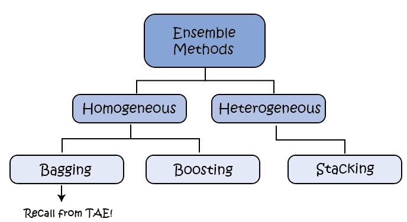

- Recall that we have learnt bagging in The Analytics Edge (TAE)

# Recall from TAE: Bagging

- Bagging is a homogeneous ensemble method
- When using bagging, weak learners are learned **independently** from each other in **parallel**

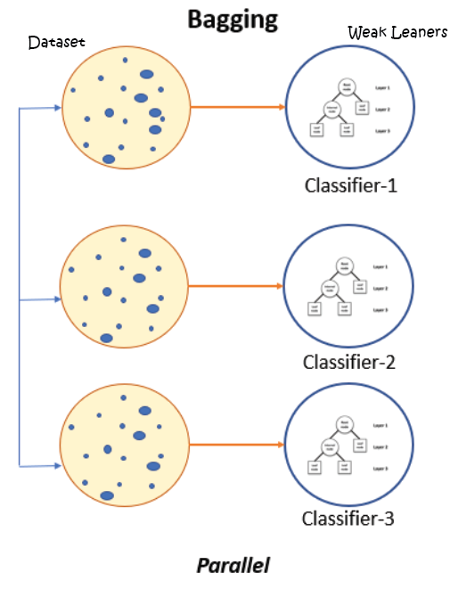

# Ensemble Methods

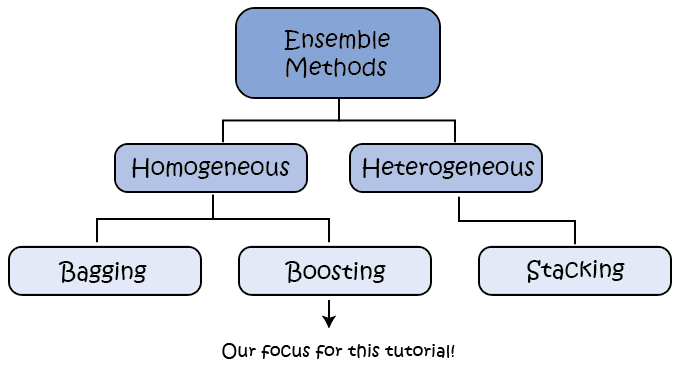

- This tutorial will be focusing on the boosting method
- Let us now take a look at the boosting method in more depth

# Boosting

- Just like bagging, boosting is also a homogeneous ensemble method
- On the other hand, when using boosting, weak learners are learned **sequentially** in a very **adaptive** way (*a base model depends on the previous ones*)
- In short, boosting seek to improve the prediction power by training a sequence of weak models , each **compensating the weaknesses of its predecessors**

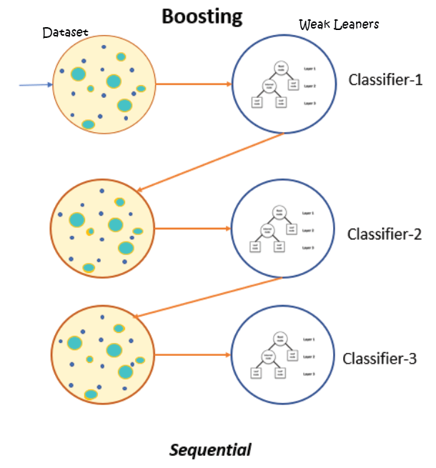

# Boosting

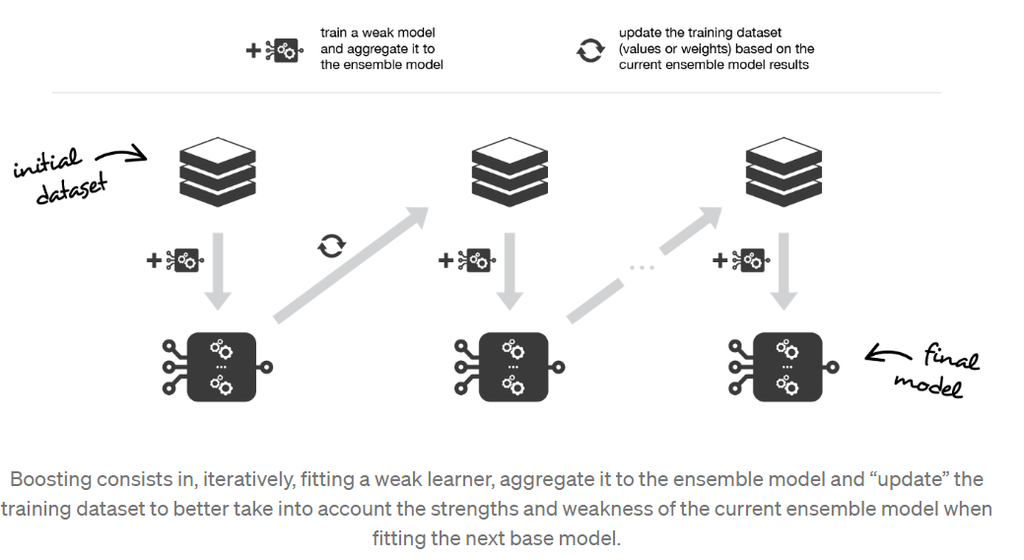

# Boosting Algorithms

- Some of the most common boosting algorithms:
- Adaptive Boosting Algorithm (Adaboost)
- Gradient Boosting Algorithm (Gboost)
- Extreme Gradient Boosting Algorithm (XGboost)
- Light Gradient Boosting Algorithm

# Boosting Algorithms

- Some of the most common boosting algorithms:
- Adaptive Boosting Algorithm (Adaboost)
- Gradient Boosting Algorithm (Gboost)
- **Extreme Gradient Boosting Algorithm (XGboost) -> we will be looking at this in more depth**
- Light Gradient Boosting Algorithm

# Backtracking

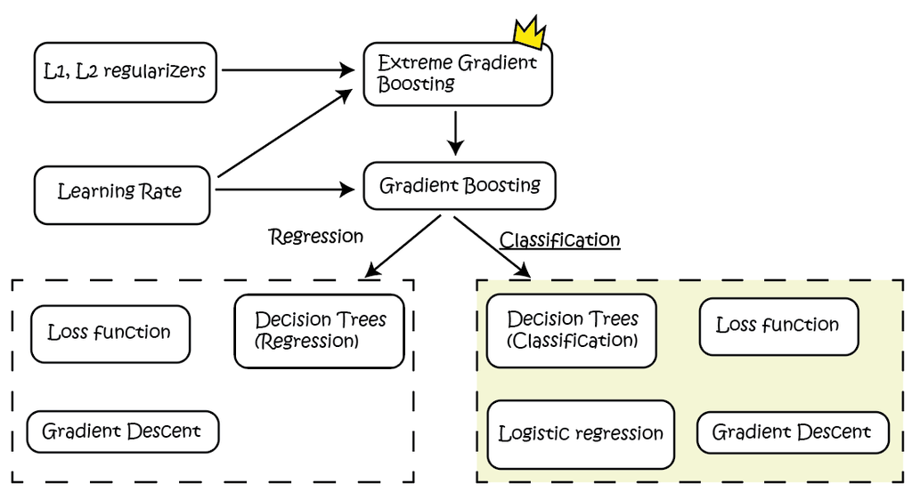

- We will be focusing on the use of *Extreme Gradient Boosting* for **classification**

# Extreme Gradient Boosting

- To understand Extreme Gradient Boosting, we will first need to understand **Gradient Boosting**

# Gradient Boosting

- Supervised Learning Algorithm
- Gradient Boosting *(Also known as Gradient Boosted Decision Trees)* uses an **ensemble of decision (classification) trees** to predict a target label

# Decision Trees (Classification)

- Recall from The Analytics Edge (TAE):
- A decision tree is a tree where each node represents a feature, each branch represents a decision and each leaf represents an outcome
- A decision tree takes a set of input features and splits input data recursively based on those input features
- This is an iterative process where there is no more branching of tree if some stop condition is met

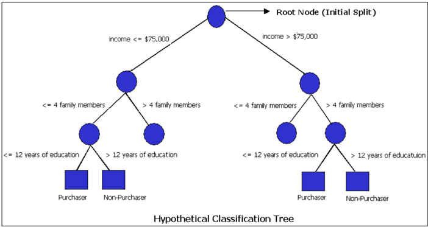

# Decision Trees (Classification)

- Recall from The Analytics Edge (TAE):
- To decide on which separation at each node is “best”, we need to measure and compare impurity

# Decision Trees (Classification) - for your knowledge

- Recall from The Analytics Edge (TAE):

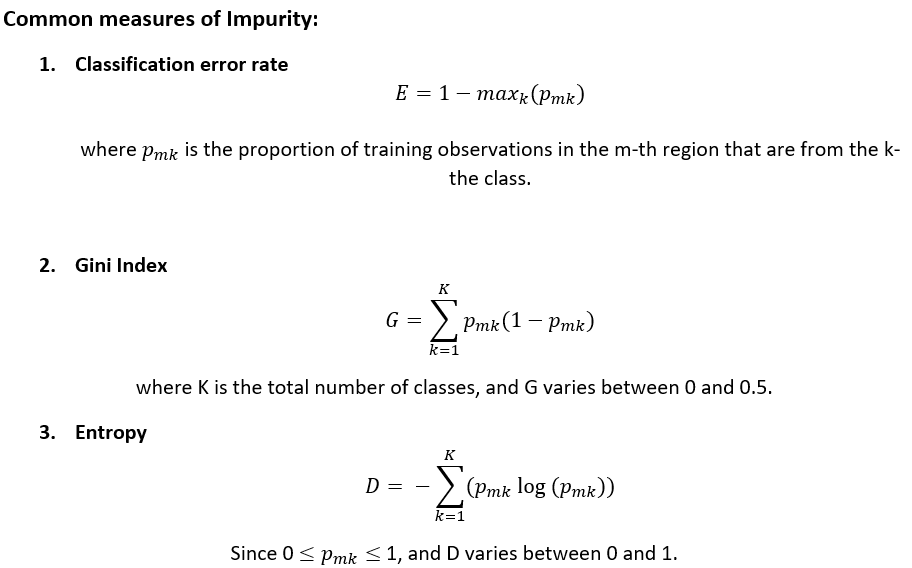